# 2022-12-31-assign-variable-type-to-funds

The assign_var_type() function takes a dictionary x as input and returns a string value based on the value of x['var_num']. The function defines a mapping between certain values of x['var_num'] and string values, and it returns the string value that corresponds to the given x['var_num'] value. If the value of x['var_num'] is not one of the predefined values, the function returns 0.

For example, if x is a dictionary with the key-value pair {'var_num': 12}, the function will return 'VA'. If x is a dictionary with the key-value pair {'var_num': 19}, the function will return 0.

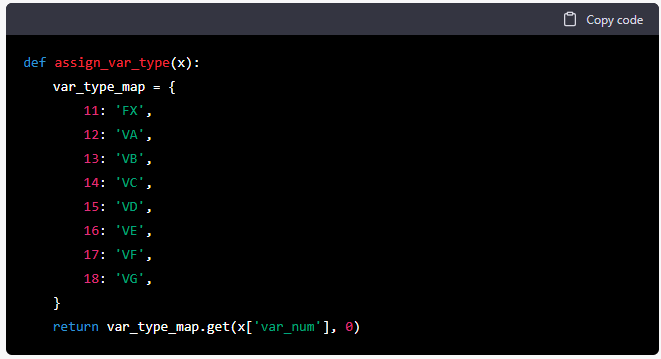

This version using list comprehension is similar to the previous version using dict.get(), but it may be slightly less efficient because it requires iterating over the dictionary to find the matching key, whereas dict.get() uses a hash table to look up the value in constant time. However, the difference in performance is likely to be minor in most cases, and the list comprehension version may be more concise and easier to read and understand for some people.

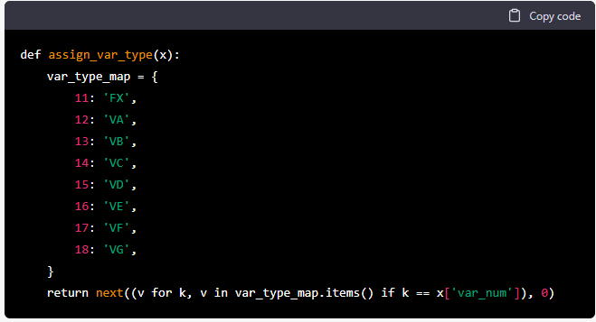